# Week 4- Color Theory

Francine Mullen

2025-02-13

# Task 1: Population Density Prediction by 2029 for Cahche County, UT

## Sequential color scheme

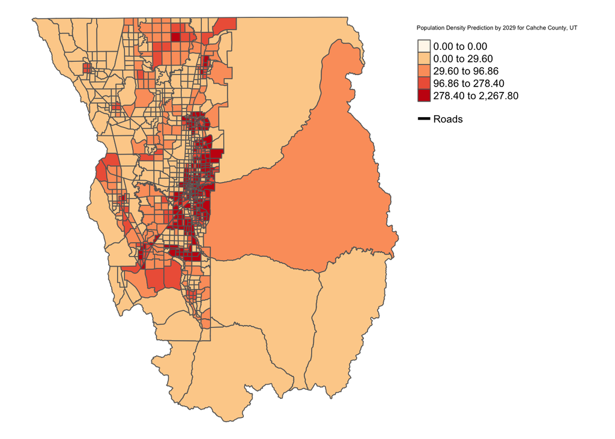

```r
library(tmap)
library(sf)
library(dplyr)
library(RColorBrewer)

# set workspace
#setwd(dirname(rstudioapi::getActiveDocumentContext()$path))

#read geometries--------------------------------------------------
tracts <- sf::st_read("/Users/francine/Downloads/W4_Ex_Code_Data/data/Cahce_pop_proj.shp", quiet=TRUE) %>%
  base::subset(., select = c("TAZID","CO_TAZID","YEAR2029"))

roads <- st_read("data/USAFreeways.shp", quiet=TRUE) %>%
  subset(., select = c())

county <- st_read("/Users/francine/Downloads/W4_Ex_Code_Data/data/cache_county.shp", quiet=TRUE) %>%
  subset(., select = c())

#check Brewer's color palettes------------------------------------
#(RColorBrewer::display.brewer.all(colorblindFriendly = TRUE)

#produce the map--------------------------------------------------
map <- tmap::tm_shape(tracts) +                 # add tracts layer
  tm_fill(                                #    specify tracts symbology
    col = "YEAR2029",                   #       which attribute determines the color?
    palette="OrRd",                       #       color palette. for other choices, see ColorBrewer's palettes
    style = "quantile",                   #       class breaks method. other choices: "cat", "fixed", "sd", "equal", "pretty", "quantile", "kmeans", "hclust", "bclust", "fisher", "jenks", "dpih", "headtails", "log10_pretty"
    title = "Population Density Prediction by 2029 for Cahche County, UT",
    subtitle = " Population values are estimated values to 2019 baseline population total") +  #       title for legend item
  tm_borders() +                          #    add polygon borders

  tm_shape(roads) +                       # add roads layer
  tm_lines(                               # specify roads symbology
    col = "black",                        #    line color
    scale = 1) +                          #    line width

  tm_layout(                              # layout arguments
    frame = FALSE,                        #    hide map frame
    legend.outside = TRUE,                #    legend outside map frame
    legend.format = list(digits = 2)) +   #    legend number format: two digits

  tm_add_legend('line',                   # add roads legend item
                col = "black",            #    color
                lwd = 3,                  #    line width
                labels = "Roads")         #    label

#display the map--------------------------------------------------
map
```

```r
#save the map-----------------------------------------------------
#tmap_save(map, "figures/population density 2029.png")
```

The population density projections for Cache County, Utah, are based on regional planning models used by Utah’s metropolitan planning organizations (MPOs), incorporating demographic, employment, and land-use data to inform long-term infrastructure planning. The legend represents the average additional individuals per census tract by 2029, with lighter shades indicating minimal growth and darker reds showing significant increases, particularly in urbanized areas like Logan. This data was obtained from the Wastach Front Regional Council and the baseline data for the projections is based off of the existing conditions from 2019, serving as a base year for the projections. https://data.wfrc.org/datasets/b22aac2dbb994a949665cb3a3fb078c1/about

# Task 2: The School Index for Salt Lake County

## Diverging Color Scheme

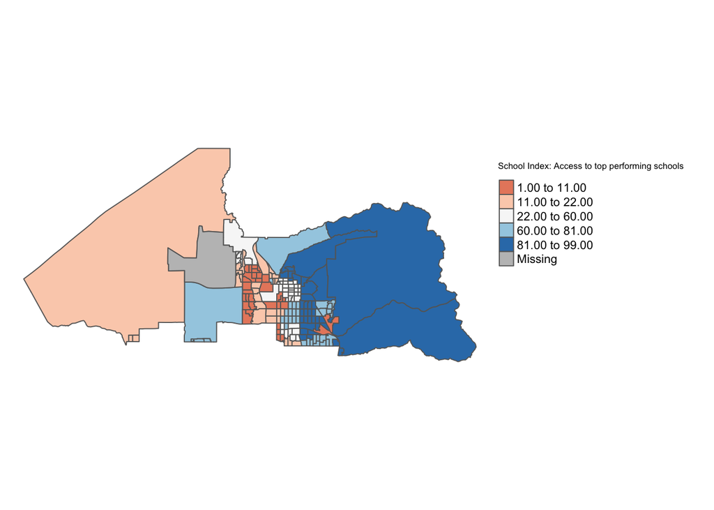

```r
library(tmap)
library(sf)
library(dplyr)
library(RColorBrewer)

# set workspace
#setwd(dirname(rstudioapi::getActiveDocumentContext()$path))

# read geometries--------------------------------------------------
counties <- sf::st_read("/Users/francine/Downloads/W4_Ex_Code_Data/data/Opportunity_Index.shp", quiet=TRUE) %>%
  base::subset(., select = c("GEOID10","school_ind"))
  #st_transform(., crs=2163)                               #Transform to US National Atlas Equal Area



# check Brewer's color palettes------------------------------------
#RColorBrewer::display.brewer.all(colorblindFriendly = TRUE)

# produce the map--------------------------------------------------
map <- tmap::tm_shape(counties) +         # add counties layer
  tm_fill(                                #    specify counties symbology
    col = "school_ind",                   #       which attribute determines the color?
    palette="RdBu",                       #       color palette
    style = "quantile",                   #       class breaks method.
    n = 5,                                #       number of classes
#    legend.hist=T,                        #       legend histogram
    title = "School Index: Access to top performing schools") +   #title for legend item
  tm_borders() +                          #    add polygon borders

  tm_layout(                              # layout arguments
    frame = FALSE,                        #    hide map frame
    legend.outside = TRUE,                #    legend outside map frame
    legend.format = list(digits = 2))   #    legend number format: two digits


# display the map--------------------------------------------------
map
```

```r
# save the map-----------------------------------------------------
#tmap_save(map, "figures/school_index.png")
```

https://gis-slcgov.opendata.arcgis.com/datasets/slcgov::opportunity-index/about

# Task 3: Higher Education Facilities

```r
# load packages----------------------------------------------------
library(tmap)
library(sf)
library(dplyr)
library(RColorBrewer)
library(pacman)

# set workspace----------------------------------------------------
#setwd(dirname(rstudioapi::getActiveDocumentContext()$path))

# switch to view mode----------------------------------------------
current.mode <- tmap_mode("view")
```

```
## tmap mode set to interactive viewing
```

```r
# read geometries--------------------------------------------------
facilities <- st_read("/Users/francine/Downloads/W4_Ex_Code_Data/data/Schools_HigherEducation.shp", quiet = TRUE) %>%
  subset(., select = c("SchoolType"))

# check Brewer's color palettes------------------------------------
#display.brewer.all(colorblindFriendly = TRUE)

# check basemap providers------------------------------------------
#leaflet::providers

# produce the map--------------------------------------------------
map <- tm_basemap(leaflet::providers$CartoDB.Positron) +
  tm_shape(
    facilities,
    bbox = "Salt Lake City, UT") +
  tm_dots(
    col = "SchoolType",
    size = .1,
    palette = "Dark2")

# display the map in RStudio---------------------------------------
map
```

[interactive chart not shown]

```r
# create leaflet widget--------------------------------------------
#lf_map <- tmap_leaflet(map)
#p_load(htmlwidgets)
#saveWidget(lf_map, file="figures/higher_ed.html")
```

The Higher Education Index map is based on the locations of public and private colleges, universities, technical colleges, and other higher education institutions in Utah. The data was sourced from Utah’s official education website and geocoded using the AGRC geocoding API to map both primary and branch campuses. The symbology of this legend is relatively neutral, not influencing if one type of college is “better” than the other. This data is to the extent of Salt Lake County.

https://opendata.gis.utah.gov/datasets/utah-schools-higher-education/about